# Project: Movies Data Analysis

- Introduction
- Data Wrangling
- Exploratory Data Analysis

**Dataset used:** TMDb dataset

## Introduction

```python
import numpy as np
import pandas as pd
import matplotlib.pyplot as plt
import seaborn as sns
%matplotlib inline
```

## Data Wrangling

### Load the Dataset

```python
df = pd.read_csv('tmdb-movies.csv')
df.head()
```

|  | id | imdb_id | popularity | budget | revenue | original_title | cast | homepage | director | tagline | ... | overview | runtime | genres | production_companies | release_date | vote_count | vote_average | release_year | budget_adj | revenue_adj |
| --- | --- | --- | --- | --- | --- | --- | --- | --- | --- | --- | --- | --- | --- | --- | --- | --- | --- | --- | --- | --- | --- |
| 0 | 135397 | tt0369610 | 32.985763 | 150000000 | 1513528810 | Jurassic World | Chris Pratt\|Bryce Dallas Howard\|Irrfan Khan\|Vi... | http://www.jurassicworld.com/ | Colin Trevorrow | The park is open. | ... | Twenty-two years after the events of Jurassic ... | 124 | Action\|Adventure\|Science Fiction\|Thriller | Universal Studios\|Amblin Entertainment\|Legenda... | 6/9/15 | 5562 | 6.5 | 2015 | 1.379999e+08 | 1.392446e+09 |
| 1 | 76341 | tt1392190 | 28.419936 | 150000000 | 378436354 | Mad Max: Fury Road | Tom Hardy\|Charlize Theron\|Hugh Keays-Byrne\|Nic... | http://www.madmaxmovie.com/ | George Miller | What a Lovely Day. | ... | An apocalyptic story set in the furthest reach... | 120 | Action\|Adventure\|Science Fiction\|Thriller | Village Roadshow Pictures\|Kennedy Miller Produ... | 5/13/15 | 6185 | 7.1 | 2015 | 1.379999e+08 | 3.481613e+08 |
| 2 | 262500 | tt2908446 | 13.112507 | 110000000 | 295238201 | Insurgent | Shailene Woodley\|Theo James\|Kate Winslet\|Ansel... | http://www.thedivergentseries.movie/#insurgent | Robert Schwentke | One Choice Can Destroy You | ... | Beatrice Prior must confront her inner demons ... | 119 | Adventure\|Science Fiction\|Thriller | Summit Entertainment\|Mandeville Films\|Red Wago... | 3/18/15 | 2480 | 6.3 | 2015 | 1.012000e+08 | 2.716190e+08 |
| 3 | 140607 | tt2488496 | 11.173104 | 200000000 | 2068178225 | Star Wars: The Force Awakens | Harrison Ford\|Mark Hamill\|Carrie Fisher\|Adam D... | http://www.starwars.com/films/star-wars-episod... | J.J. Abrams | Every generation has a story. | ... | Thirty years after defeating the Galactic Empi... | 136 | Action\|Adventure\|Science Fiction\|Fantasy | Lucasfilm\|Truenorth Productions\|Bad Robot | 12/15/15 | 5292 | 7.5 | 2015 | 1.839999e+08 | 1.902723e+09 |
| 4 | 168259 | tt2820852 | 9.335014 | 190000000 | 1506249360 | Furious 7 | Vin Diesel\|Paul Walker\|Jason Statham\|Michelle ... | http://www.furious7.com/ | James Wan | Vengeance Hits Home | ... | Deckard Shaw seeks revenge against Dominic Tor... | 137 | Action\|Crime\|Thriller | Universal Pictures\|Original Film\|Media Rights ... | 4/1/15 | 2947 | 7.3 | 2015 | 1.747999e+08 | 1.385749e+09 |

5 rows × 21 columns

### Investigate the dataset

```python
df.info()
```

```
<class 'pandas.core.frame.DataFrame'>
RangeIndex: 10866 entries, 0 to 10865
Data columns (total 21 columns):
id                      10866 non-null int64
imdb_id                 10856 non-null object
popularity              10866 non-null float64
budget                  10866 non-null int64
revenue                 10866 non-null int64
original_title          10866 non-null object
cast                    10790 non-null object
homepage                2936 non-null object
director                10822 non-null object
tagline                 8042 non-null object
keywords                9373 non-null object
overview                10862 non-null object
runtime                 10866 non-null int64
genres                  10843 non-null object
production_companies    9836 non-null object
release_date            10866 non-null object
vote_count              10866 non-null int64
vote_average            10866 non-null float64
release_year            10866 non-null int64
budget_adj              10866 non-null float64
revenue_adj             10866 non-null float64
dtypes: float64(4), int64(6), object(11)
memory usage: 1.7+ MB
```

```python
df.isnull().sum()
```

```
id                         0
imdb_id                   10
popularity                 0
budget                     0
revenue                    0
original_title             0
cast                      76
homepage                7930
director                  44
tagline                 2824
keywords                1493
overview                   4
runtime                    0
genres                    23
production_companies    1030
release_date               0
vote_count                 0
vote_average               0
release_year               0
budget_adj                 0
revenue_adj                0
dtype: int64
```

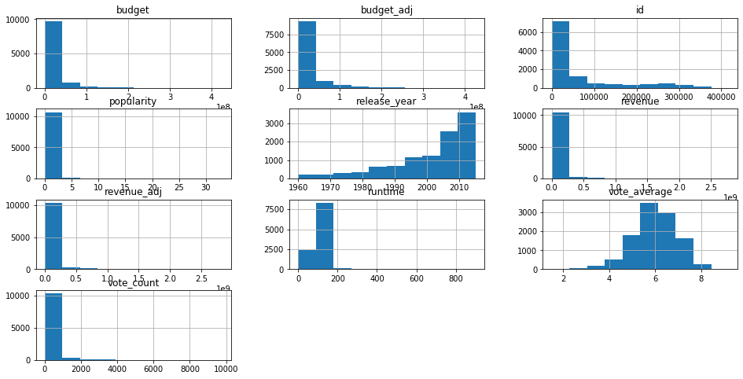

```python
df.hist(figsize=(16,8));
```

```python
df.columns
```

```
Index(['id', 'imdb_id', 'popularity', 'budget', 'revenue', 'original_title',
       'cast', 'homepage', 'director', 'tagline', 'keywords', 'overview',
       'runtime', 'genres', 'production_companies', 'release_date',
       'vote_count', 'vote_average', 'release_year', 'budget_adj',
       'revenue_adj'],
      dtype='object')
```

```python
df.duplicated().sum()
```

```
1
```

- Issues
  - one duplicate
  - `id` should be string
  - `release_date` should be datetime

#### `release_year` column

```python
#Search for categorical variables
df['release_year'].value_counts().sort_values(ascending=False).head(15)
```

```
2014    700
2013    659
2015    629
2012    588
2011    540
2009    533
2008    496
2010    490
2007    438
2006    408
2005    364
2004    307
2003    281
2002    266
2001    242
Name: release_year, dtype: int64
```

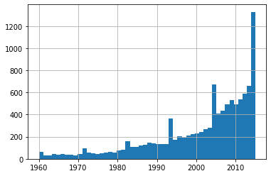

```python
df['release_year'].hist(bins=50);
```

#### `director` column

```python
df['director'].value_counts().sort_values(ascending=False).head(15)
```

```
Woody Allen          45
Clint Eastwood       34
Martin Scorsese      29
Steven Spielberg     29
Ridley Scott         23
Steven Soderbergh    22
Ron Howard           22
Joel Schumacher      21
Brian De Palma       20
Tim Burton           19
Wes Craven           19
Barry Levinson       19
Rob Reiner           18
Mike Nichols         18
David Cronenberg     18
Name: director, dtype: int64
```

#### `original_title` column

```python
df['original_title'].value_counts().head(15)
```

```
Hamlet                  4
The Black Hole          3
Jane Eyre               3
Oliver Twist            3
Annie                   3
Alice in Wonderland     3
Hercules                3
Life                    3
Wuthering Heights       3
Carrie                  3
Emma                    3
Beauty and the Beast    3
Frankenstein            3
Shelter                 3
The Three Musketeers    3
Name: original_title, dtype: int64
```

It's not strange that there are many repeated titles, because famous movies are re-acted but let's check!

```python
df[df['original_title'] == 'Hamlet']
```

|  | id | imdb_id | popularity | budget | revenue | original_title | cast | homepage | director | tagline | ... | overview | runtime | genres | production_companies | release_date | vote_count | vote_average | release_year | budget_adj | revenue_adj |
| --- | --- | --- | --- | --- | --- | --- | --- | --- | --- | --- | --- | --- | --- | --- | --- | --- | --- | --- | --- | --- | --- |
| 1890 | 28238 | tt1449175 | 0.086490 | 0 | 0 | Hamlet | David Tennant\|Patrick Stewart\|Penny Downie\|Oli... | http://www.bbc.co.uk/hamlet/ | Gregory Doran | To be, or not to be? | ... | David Tennant stars in a film of the Royal Sha... | 185 | Drama | NHK Enterprises\|Illuminations\|BBC Wales | 12/26/09 | 13 | 6.4 | 2009 | 0.000000e+00 | 0.000000e+00 |
| 8573 | 10549 | tt0116477 | 0.383469 | 0 | 0 | Hamlet | Kenneth Branagh\|Derek Jacobi\|Julie Christie\|Ri... | NaN | Kenneth Branagh | NaN | ... | Hamlet, Prince of Denmark, returns home to fin... | 242 | Drama | Castle Rock Entertainment\|Turner Pictures (I) | 12/25/96 | 51 | 6.7 | 1996 | 0.000000e+00 | 0.000000e+00 |
| 8797 | 10688 | tt0171359 | 0.277798 | 2000000 | 1568749 | Hamlet | Ethan Hawke\|Kyle MacLachlan\|Diane Venora\|Sam S... | NaN | Michael Almereyda | Passion, Betrayal, Revenge, A hostile takeover... | ... | Modern day adaptation of Shakespeare's immorta... | 112 | Drama | Miramax Films\|double A Films | 5/12/00 | 18 | 5.0 | 2000 | 2.532584e+06 | 1.986494e+06 |
| 10106 | 10264 | tt0099726 | 0.067973 | 0 | 20710451 | Hamlet | Mel Gibson\|Glenn Close\|Alan Bates\|Paul Scofiel... | NaN | Franco Zeffirelli | The extraordinary adaptation of Shakespeare's ... | ... | Hamlet, Prince of Denmark, finds out that his ... | 130 | Drama\|History | Icon Productions\|Warner Bros. Pictures\|Nelson ... | 12/19/90 | 43 | 6.5 | 1990 | 0.000000e+00 | 3.456364e+07 |

4 rows × 21 columns

```python
df[df['original_title'] == 'Carrie']
```

|  | id | imdb_id | popularity | budget | revenue | original_title | cast | homepage | director | tagline | ... | overview | runtime | genres | production_companies | release_date | vote_count | vote_average | release_year | budget_adj | revenue_adj |
| --- | --- | --- | --- | --- | --- | --- | --- | --- | --- | --- | --- | --- | --- | --- | --- | --- | --- | --- | --- | --- | --- |
| 4101 | 7342 | tt0319970 | 0.257263 | 0 | 0 | Carrie | Angela Bettis\|Patricia Clarkson\|Rena Sofer\|Kan... | NaN | David Carson | NaN | ... | Carrie White is a lonely and painfully shy tee... | 132 | Drama\|Horror | MGM Television\|Trilogy Entertainment Group | 11/4/02 | 53 | 5.5 | 2002 | 0.000000e+00 | 0.000000e+00 |
| 5486 | 133805 | tt1939659 | 1.412233 | 30000000 | 82394288 | Carrie | Chloë Grace Moretz\|Julianne Moore\|Judy Greer\|... | http://www.carrie-movie.com | Kimberly Peirce | Know her name. Fear her power. | ... | A reimagining of the classic horror tale about... | 100 | Drama\|Horror | Screen Gems\|Metro-Goldwyn-Mayer (MGM)\|Misher F... | 10/16/13 | 897 | 5.8 | 2013 | 2.808100e+07 | 7.712380e+07 |
| 10175 | 7340 | tt0074285 | 1.263483 | 1800000 | 33800000 | Carrie | Sissy Spacek\|Piper Laurie\|Amy Irving\|William K... | NaN | Brian De Palma | If you’ve got a taste for terror... take Car... | ... | Carrie may be ostracized, but the shy teen has... | 98 | Horror\|Thriller | United Artists | 11/3/76 | 497 | 6.8 | 1976 | 6.897056e+06 | 1.295114e+08 |

3 rows × 21 columns

```python
df[df['original_title'] == 'Annie']
```

|  | id | imdb_id | popularity | budget | revenue | original_title | cast | homepage | director | tagline | ... | overview | runtime | genres | production_companies | release_date | vote_count | vote_average | release_year | budget_adj | revenue_adj |
| --- | --- | --- | --- | --- | --- | --- | --- | --- | --- | --- | --- | --- | --- | --- | --- | --- | --- | --- | --- | --- | --- |
| 724 | 196867 | tt1823664 | 1.588010 | 65000000 | 133821816 | Annie | QuvenzhanÃ© Wallis\|Jamie Foxx\|Rose Byrne\|Camer... | NaN | Will Gluck | It's a Hard Knock Life | ... | Ever since her parents left her as a baby, lit... | 119 | Music\|Comedy\|Drama\|Family | Columbia Pictures\|Sony Pictures Entertainment ... | 12/19/14 | 331 | 6.1 | 2014 | 5.987092e+07 | 1.232621e+08 |
| 2485 | 26177 | tt0207972 | 0.548720 | 0 | 0 | Annie | Kathy Bates\|Victor Garber\|Alan Cumming\|Audra M... | NaN | Rob Marshall | Disney makes the classical musical more magica... | ... | Eleven-year-old Annie has been living in an or... | 90 | Music\|Family\|Comedy | Walt Disney Television\|Storyline Entertainment... | 11/7/99 | 35 | 5.5 | 1999 | 0.000000e+00 | 0.000000e+00 |
| 8920 | 15739 | tt0083564 | 0.421748 | 50000000 | 57059003 | Annie | Aileen Quinn\|Albert Finney\|Carol Burnett\|Ann R... | NaN | John Huston | The movie of 'Tomorrow' | ... | An orphan in a facility run by the mean Miss H... | 127 | Comedy\|Drama\|Family\|Music | Columbia Pictures\|Rastar Pictures | 6/18/82 | 99 | 6.2 | 1982 | 1.129821e+08 | 1.289329e+08 |

3 rows × 21 columns

Cool, they're not duplicates. No worries here.

#### `homepage` column

```python
df['homepage'].isnull().sum()
```

```
7930
```

```python
df['homepage'].sample(10)
```

```
9777                                      NaN
1452             http://www.munkyourself.com/
3650          http://www.blackthornmovie.com/
3944          http://movies.uip.de/aboutaboy/
7717               http://hannibalrising.com/
8617                                      NaN
10078    http://www.imdb.com/title/tt0100133/
1939            http://www.truegritmovie.com/
1021         http://www.thedarkhorsefilm.com/
919                                       NaN
Name: homepage, dtype: object
```

Looks like the column `homepage` won't be of much use, since it's has many nans

#### `tagline` column

```python
# Can't really imagine what tagline column might be like
df['tagline'].sample(10)
```

```
4997                              Don't mess with the hat.
2060                          Every secret dies somewhere.
10677                                         A man called
9377                                                   NaN
8936     ...the most devastating killing machine ever b...
3447     His twin sister is coming for the holidays... ...
3510                                    Cancel Your Future
1568                                 Where is Alice Creed?
656                   The Film Hackers Tried To Get Banned
3015                                                   NaN
Name: tagline, dtype: object
```

```python
df['tagline'].isnull().sum()
```

```
2824
```

#### `keywords` column

```python
df['keywords'].sample(10)
```

```
8164                                   puberty|first time
6319                        family relationships|dinosaur
4921                                                  NaN
2777        sheriff|horse|outlaw|jesse james|cole younger
6808    dormitory|art school|independent film|serial k...
1626                                     independent film
7632                               ventriloquist|stand-up
8612        gambling|prostitute|casino|cheating|blackmail
7357                                                bully
9478    free love|infidelity|loyalty|union of soviet s...
Name: keywords, dtype: object
```

```python
df['keywords'].value_counts().head(15)
```

```
woman director                     134
independent film                    82
sport                               25
musical                             24
suspense                            24
duringcreditsstinger                24
holiday                             16
stand-up|stand up comedy            16
biography                           15
independent film|woman director     13
stand up comedy                      9
based on novel                       7
holiday|christmas                    7
dystopia                             7
found footage                        7
Name: keywords, dtype: int64
```

```python
df['keywords'].isnull().sum()
```

```
1493
```

#### `overview` column

```python
df['overview'].value_counts()
```

```
No overview found.                                                                                                                                                                                                                                                                                          …
In the year of 2039, after World Wars destroy much of the civilization as we know it, territories are no longer run by governments, but by corporations; the mightiest of which is the Mishima Zaibatsu. In order to placate the seething masses of this dystopia, Mishima sponsors Tekken, a tournament in …
Wilbur the pig is scared of the end of the season, because he knows that come that time, he will end up on the dinner table. He hatches a plan with Charlotte, a spider that lives in his pen, to ensure that this will never happen.                                                                       …
1960. The thrilling battles waged by a band of kids from two rival villages in the southern French countryside.                                                                                                                                                                                             …
A tormented jazz musician finds himself lost in an enigmatic story involving murder, surveillance, gangsters, doppelgangers, and an impossible transformation inside a prison cell.                                                                                                                         …
                                                                                                                                                                                                                                                                                                            …
Little Victoria is waken up by her sister Lili who insists on leaving the house because somebody unpleasant has come back.                                                                                                                                                                                  …
The coming of age of a youth named Sonny in a small Texas town in the 1950s.                                                                                                                                                                                                                                …
Mistaken for Strangers follows The National on its biggest tour to date. Newbie roadie Tom (lead singer Matt Berningerâ€™s younger brother) is a heavy metal and horror movie enthusiast, and can't help but put his own spin on the experience. Inevitably, Tomâ€™s moonlighting as an irreverent documenta…
Treasure Island is a two-part British television miniseries adaptation of the novel Treasure Island by Robert Louis Stevenson. It was made by BSkyB and first shown in the United Kingdom on Sky1 on 1â€“2 January 2012. The screenplay was by Stewart Harcourt and it was produced by Laurie Borg and direc…
A joint American-Soviet space expedition is sent to Jupiter to learn went happened to the U.S.S. Discovery against a backdrop of growing global tensions. Among the mysteries the expedition must explain are the appearance of a huge black monolith in Jupiter's orbit and the fate of H.A.L., the Discove…
Name: overview, Length: 10847, dtype: int64
```

```python
useless_overviews = sum(df['overview'].isnull()) + sum(df['overview'] == 'No overview found.')
useless_overviews
```

```
17
```

#### `production_companies` column

```python
df['production_companies'].value_counts().head(25)
```

```
Paramount Pictures                              156
Universal Pictures                              133
Warner Bros.                                     84
Walt Disney Pictures                             76
Columbia Pictures                                72
Metro-Goldwyn-Mayer (MGM)                        72
New Line Cinema                                  61
Touchstone Pictures                              51
20th Century Fox                                 50
Twentieth Century Fox Film Corporation           49
TriStar Pictures                                 45
Orion Pictures                                   42
Miramax Films                                    32
DreamWorks Animation                             31
Columbia Pictures Corporation                    31
Pixar Animation Studios                          30
Walt Disney Productions                          29
Dimension Films                                  28
United Artists                                   23
Marvel Studios                                   22
Imagine Entertainment|Universal Pictures         22
The Asylum                                       21
Lions Gate Films                                 21
New World Pictures                               17
Walt Disney Pictures|Pixar Animation Studios     17
Name: production_companies, dtype: int64
```

#### `release_date` column

```python
df['release_date'].sample(10)
```

```
254      9/15/15
5229     4/25/03
9543      4/1/88
8124      8/4/95
6368    12/31/05
1585     9/12/09
6969     5/13/04
9383     10/4/91
8359    12/17/92
4943     1/22/12
Name: release_date, dtype: object
```

#### `vote_count` column

```python
df['vote_count'].sample(10)
```

```
1853      16
6988    1131
3154      28
9681      12
1895      25
6141      13
8785      21
5340      41
7504     460
6321      70
Name: vote_count, dtype: int64
```

```python
#to get a sense of the numbers
df['vote_count'].describe()
```

```
count    10866.000000
mean       217.389748
std        575.619058
min         10.000000
25%         17.000000
50%         38.000000
75%        145.750000
max       9767.000000
Name: vote_count, dtype: float64
```

#### `popularity` column

```python
#to get a sense of the numbers
df['popularity'].describe()
```

```
count    10866.000000
mean         0.646441
std          1.000185
min          0.000065
25%          0.207583
50%          0.383856
75%          0.713817
max         32.985763
Name: popularity, dtype: float64
```

```python
df['popularity'].min()
```

```
6.500000000000001e-05
```

```python
df[df['popularity'] == df['popularity'].min()]
```

|  | id | imdb_id | popularity | budget | revenue | original_title | cast | homepage | director | tagline | ... | overview | runtime | genres | production_companies | release_date | vote_count | vote_average | release_year | budget_adj | revenue_adj |
| --- | --- | --- | --- | --- | --- | --- | --- | --- | --- | --- | --- | --- | --- | --- | --- | --- | --- | --- | --- | --- | --- |
| 6181 | 18729 | tt0088583 | 0.000065 | 0 | 0 | North and South, Book I | Patrick Swayze\|Philip Casnoff\|Kirstie Alley\|Ge... | NaN | NaN | NaN | ... | Two friends, one northern and one southern, st... | 561 | Drama\|History\|Western | NaN | 11/3/85 | 17 | 6.0 | 1985 | 0.0 | 0.0 |

1 rows × 21 columns

Runtime is 561 mins which is wierd!!

#### `runtime` column

```python
sum(df['runtime'] >= 180)
```

```
145
```

Apparantly, there's something wrong

```python
df[df['runtime'] >= 180].sample(5)
```

|  | id | imdb_id | popularity | budget | revenue | original_title | cast | homepage | director | tagline | ... | overview | runtime | genres | production_companies | release_date | vote_count | vote_average | release_year | budget_adj | revenue_adj |
| --- | --- | --- | --- | --- | --- | --- | --- | --- | --- | --- | --- | --- | --- | --- | --- | --- | --- | --- | --- | --- | --- |
| 9758 | 240 | tt0071562 | 3.264571 | 13000000 | 47542841 | The Godfather: Part II | Al Pacino\|Robert Duvall\|Diane Keaton\|Robert De... | NaN | Francis Ford Coppola | I don't feel I have to wipe everybody out, Tom... | ... | In the continuing saga of the Corleone crime f... | 200 | Drama\|Crime | Paramount Pictures\|The Coppola Company | 12/20/74 | 2131 | 8.1 | 1974 | 5.748969e+07 | 2.102479e+08 |
| 4788 | 139777 | tt1878805 | 0.179240 | 0 | 0 | World Without End | Ben Chaplin\|Charlotte Riley\|Cynthia Nixon\|Carl... | NaN | Michael Caton-Jones | NaN | ... | The English town of Kingsbridge works to survi... | 389 | Drama\|History\|Romance | Scott Free Productions\|Tandem Communications\|G... | 1/1/12 | 10 | 6.1 | 2012 | 0.000000e+00 | 0.000000e+00 |
| 3708 | 76115 | tt2077886 | 0.295301 | 0 | 0 | The Phantom of the Opera at the Royal Albert Hall | Ramin Karimloo\|Sierra Boggess\|Hadley Fraser\|Ki... | NaN | Nick Morris\|Laurence Connor | Be Seduced | ... | A disfigured musical genius, hidden away in th... | 202 | Drama\|Music\|Romance | THE REALLY USEFUL THEATRE COMPANY PRODUCTION\|C... | 9/27/11 | 15 | 7.6 | 2011 | 0.000000e+00 | 0.000000e+00 |
| 2222 | 63561 | tt2009776 | 0.279938 | 0 | 0 | Ben Hur | Joseph Morgan\|Stephen Campbell Moore\|Emily Van... | NaN | Steve Shill | NaN | ... | About the struggle between the Roman Empire an... | 184 | Family\|History\|Action\|Drama | Akkord Film Produktion GmbH\|Drimtim Entertainm... | 5/1/10 | 14 | 6.4 | 2010 | 0.000000e+00 | 0.000000e+00 |
| 10143 | 967 | tt0054331 | 1.136943 | 12000000 | 60000000 | Spartacus | Kirk Douglas\|Laurence Olivier\|Jean Simmons\|Cha... | NaN | Stanley Kubrick | More titanic than any story ever told! | ... | Spartacus is a 1960 American historical drama ... | 197 | Action\|Drama\|History | Bryna Productions | 10/6/60 | 211 | 6.9 | 1960 | 8.847561e+07 | 4.423780e+08 |

5 rows × 21 columns

The dataset has movies and series/miniseries which is considered a tidiness issue

#### `genres` column

```python
df['genres'].value_counts().sort_values(ascending=False).head(15)
```

```
Comedy                  712
Drama                   712
Documentary             312
Drama|Romance           289
Comedy|Drama            280
Comedy|Romance          268
Horror|Thriller         259
Horror                  253
Comedy|Drama|Romance    222
Drama|Thriller          138
Comedy|Family           102
Action|Thriller         101
Thriller                 93
Drama|Comedy             92
Animation|Family         90
Name: genres, dtype: int64
```

#### `budget` & `budget_adj` columns

```python
#to get a sense of the range of values in the budget column
df['budget'].describe()
```

```
count    1.086600e+04
mean     1.462570e+07
std      3.091321e+07
min      0.000000e+00
25%      0.000000e+00
50%      0.000000e+00
75%      1.500000e+07
max      4.250000e+08
Name: budget, dtype: float64
```

```python
#because it doesn't make sense to have a budget of zero
df[df['budget'] == 0].sample(3)
```

|  | id | imdb_id | popularity | budget | revenue | original_title | cast | homepage | director | tagline | ... | overview | runtime | genres | production_companies | release_date | vote_count | vote_average | release_year | budget_adj | revenue_adj |
| --- | --- | --- | --- | --- | --- | --- | --- | --- | --- | --- | --- | --- | --- | --- | --- | --- | --- | --- | --- | --- | --- |
| 597 | 332177 | tt3746298 | 0.051107 | 0 | 0 | Vendetta | Dean Cain\|Kyra Zagorsky\|Benjamin Hollingsworth... | NaN | Jen Soska\|Sylvia Soska | Get Ready for Hell in a Cell | ... | A hard-nosed detective deliberately commits a ... | 90 | Action | WWE Studios | 6/12/15 | 22 | 5.9 | 2015 | 0.0 | 0.000000e+00 |
| 9282 | 1380 | tt0097438 | 0.209028 | 0 | 2777280 | Gleaming the Cube | Christian Slater\|Tony Hawk\|Stacy Peralta\|Rodne... | NaN | Graeme Clifford | NaN | ... | The cult classic 80â€™s B-film where the slack... | 109 | Drama | Twentieth Century Fox Film Corporation | 1/1/89 | 11 | 5.7 | 1989 | 0.0 | 4.885194e+06 |
| 9664 | 39507 | tt0092843 | 0.315932 | 0 | 0 | The Dead | Anjelica Huston\|Donal McCann\|Dan O'Herlihy\|Hel... | NaN | John Huston | A vast, merry, and uncommon tale of love. | ... | An all-Irish cast (including Donal McCann, Rac... | 83 | Drama | Zenith Entertainment\|Vestron Pictures\|Delta fi... | 9/3/87 | 13 | 6.1 | 1987 | 0.0 | 0.000000e+00 |

3 rows × 21 columns

```python
# let's check if we can fix them by using the 2010 dollar values
df['budget_adj'].min()
```

```
0.0
```

```python
df['budget_adj'].describe()
```

```
count    1.086600e+04
mean     1.755104e+07
std      3.430616e+07
min      0.000000e+00
25%      0.000000e+00
50%      0.000000e+00
75%      2.085325e+07
max      4.250000e+08
Name: budget_adj, dtype: float64
```

#### `revenue` & `revenue_adj` columns

```python
# to get a sense of the range of values in revenue
df['revenue'].describe()
```

```
count    1.086600e+04
mean     3.982332e+07
std      1.170035e+08
min      0.000000e+00
25%      0.000000e+00
50%      0.000000e+00
75%      2.400000e+07
max      2.781506e+09
Name: revenue, dtype: float64
```

```python
sum(df['revenue'] == 0)
```

```
6016
```

```python
sum(df['revenue'] != 0)
```

```
4850
```

```python
# to get a sense of the range of values in revenue
df['revenue_adj'].describe()
```

```
count    1.086600e+04
mean     5.136436e+07
std      1.446325e+08
min      0.000000e+00
25%      0.000000e+00
50%      0.000000e+00
75%      3.369710e+07
max      2.827124e+09
Name: revenue_adj, dtype: float64
```

```python
df[df['revenue'] == df['revenue'].min()].sample(3)
```

|  | id | imdb_id | popularity | budget | revenue | original_title | cast | homepage | director | tagline | ... | overview | runtime | genres | production_companies | release_date | vote_count | vote_average | release_year | budget_adj | revenue_adj |
| --- | --- | --- | --- | --- | --- | --- | --- | --- | --- | --- | --- | --- | --- | --- | --- | --- | --- | --- | --- | --- | --- |
| 7966 | 83223 | tt0086176 | 0.198438 | 0 | 0 | Rats - Notte di terrore | Ottaviano Dell'Acqua\|Geretta Geretta\|Massimo V... | NaN | Bruno Mattei\|Claudio Fragasso | Mutants of a nuclear disaster | ... | One hundred years after a nuclear war has deva... | 97 | Horror\|Science Fiction | Beatrice Film | 8/3/84 | 11 | 4.4 | 1984 | 0.000000e+00 | 0.0 |
| 7137 | 12902 | tt0418141 | 0.368223 | 0 | 0 | Scooby-Doo! and the Loch Ness Monster | Frank Welker\|Casey Kasem\|Mindy Cohn\|Grey Griff... | NaN | Scott Jeralds\|Joe Sichta | NaN | ... | Scooby-Doo, Shaggy, and the Mystery Inc. crew ... | 74 | Animation\|Family\|Comedy | Hanna-Barbera Productions | 6/21/04 | 14 | 6.3 | 2004 | 0.000000e+00 | 0.0 |
| 5866 | 246569 | tt2934844 | 0.211825 | 5000000 | 0 | Jinxed | Ciara Bravo\|Jack Griffo\|Jacob Bertrand\|Elena K... | NaN | NaN | NaN | ... | Meet the Murphys, a family with never ending b... | 75 | Family\|Fantasy\|Comedy | NaN | 11/29/13 | 19 | 7.0 | 2013 | 4.680167e+06 | 0.0 |

3 rows × 21 columns

```python
df[df['revenue_adj'] == df['revenue_adj'].min()].sample(3)
```

|  | id | imdb_id | popularity | budget | revenue | original_title | cast | homepage | director | tagline | ... | overview | runtime | genres | production_companies | release_date | vote_count | vote_average | release_year | budget_adj | revenue_adj |
| --- | --- | --- | --- | --- | --- | --- | --- | --- | --- | --- | --- | --- | --- | --- | --- | --- | --- | --- | --- | --- | --- |
| 5808 | 157117 | tt2306745 | 0.277349 | 0 | 0 | Sound City | Trent Reznor\|Tom Petty\|Mick Fleetwood\|Dave Gro... | http://www.soundcitymovie.com | Dave Grohl | That board. That room. That is Sound City. | ... | The history of Sound City and their huge recor... | 106 | Documentary\|Music | Roswell Films\|Therapy Content | 1/18/13 | 64 | 7.5 | 2013 | 0.000000 | 0.0 |
| 5513 | 157370 | tt1311071 | 1.138355 | 1030064 | 0 | Kill Your Darlings | Daniel Radcliffe\|Elizabeth Olsen\|Michael C. Ha... | NaN | John Krokidas | A true story of obsession and murder. | ... | A murder in 1944 draws together the great poet... | 104 | Drama\|Romance\|Thriller | Killer Films | 10/4/13 | 270 | 6.7 | 2013 | 964174.259457 | 0.0 |
| 3600 | 78080 | tt1855134 | 0.482803 | 0 | 0 | Beethoven's Christmas Adventure | Curtis Armstrong\|Tom Arnold\|John Cleese\|Kim Rh... | NaN | John Putch | NaN | ... | A Christmas elf accidentally takes off in Sant... | 90 | Comedy\|Family | Universal Pictures | 11/8/11 | 13 | 5.4 | 2011 | 0.000000 | 0.0 |

3 rows × 21 columns

#### `vote_average` column

```python
# to get a sense of the vote average
df['vote_average'].describe()
```

```
count    10866.000000
mean         5.974922
std          0.935142
min          1.500000
25%          5.400000
50%          6.000000
75%          6.600000
max          9.200000
Name: vote_average, dtype: float64
```

```python
df['vote_average'].value_counts().head(15)
```

```
6.1    496
6.0    495
5.8    486
5.9    473
6.2    464
6.3    461
6.5    457
6.4    446
5.7    415
6.6    413
5.6    412
5.5    380
6.7    376
5.3    358
5.4    338
Name: vote_average, dtype: int64
```

This means that `vote_average` ranges from 1 to 10.

**Issues that need to be cleaned:**

- Filling the empty string values with "empty"
- one duplicate
- `id` should be string
- `release_date` should be datetime
- Remove the series and miniseries into a separate table
- Columns to be dropped(because we won't use them):
  - imdb_id
  - budget_adj
  - revenue_adj
  - overview
  - tagline

### Data Cleaning

```python
# Make a copy of the clean data
movies = df.copy()
```

#### Filling the empty string values

```python
movies.isnull().sum()
```

```
id                         0
imdb_id                   10
popularity                 0
budget                     0
revenue                    0
original_title             0
cast                      76
homepage                7930
director                  44
tagline                 2824
keywords                1493
overview                   4
runtime                    0
genres                    23
production_companies    1030
release_date               0
vote_count                 0
vote_average               0
release_year               0
budget_adj                 0
revenue_adj                0
dtype: int64
```

```python
movies.fillna("empty", inplace=True)
```

```python
movies.isnull().sum()
```

```
id                      0
imdb_id                 0
popularity              0
budget                  0
revenue                 0
original_title          0
cast                    0
homepage                0
director                0
tagline                 0
keywords                0
overview                0
runtime                 0
genres                  0
production_companies    0
release_date            0
vote_count              0
vote_average            0
release_year            0
budget_adj              0
revenue_adj             0
dtype: int64
```

#### Removing the duplicate

```python
movies.drop_duplicates(inplace=True)
```

```python
# Just to check
movies.duplicated().sum()
```

```
0
```

#### Fixing the `id` column

```python
movies['id'].dtype
```

```
dtype('int64')
```

```python
movies['id'] = movies['id'].astype(str)
```

```python
# To check
movies['id'].dtype
```

```
dtype('O')
```

#### Fixing the `release_date` column

```python
movies['release_date'].dtype
```

```
dtype('O')
```

```python
movies['release_date'].sample()
```

```
4368    5/30/12
Name: release_date, dtype: object
```

The given order is month/day/year. We can take the year from the `release_year` column

```python
# Removing the last 2 characters (which indicate the year) and adding the year from the release_year column
movies['release_date'] = movies['release_date'].map(lambda x: x[:-2])
movies['release_date'] = movies['release_date'] + movies['release_year'].astype(str)
```

```python
movies['release_date'].sample()
```

```
3682    1/2/2011
Name: release_date, dtype: object
```

```python
# Changing the type into datetime
pd.to_datetime(movies['release_date'], format='%m/%d/%Y')
```

```
0       2015-06-09
1       2015-05-13
2       2015-03-18
3       2015-12-15
4       2015-04-01
           ...
10861   1966-06-15
10862   1966-12-21
10863   1966-01-01
10864   1966-11-02
10865   1966-11-15
Name: release_date, Length: 10865, dtype: datetime64[ns]
```

#### Drop the unnecessary columns

```python
to_be_dropped_columns = ['imdb_id', 'budget_adj', 'revenue_adj', 'overview', 'tagline']
movies.drop(to_be_dropped_columns, axis=1, inplace=True)
# Just to check
movies.shape
```

```
(10865, 16)
```

#### Splitting the table into 2 tables

```python
movies.shape
```

```
(10865, 16)
```

```python
series = pd.DataFrame(movies[movies['runtime'] > 180 ])
```

```python
series.shape
```

```
(128, 16)
```

## Exploratory Data Analysis

**Questions Addressed**

- Which genres are most popular?
- Do certain genres get a higher budget than others?
- Which directors are the most popular?
- Which movies are the best?
- Does the movie budget affect its popularity?
- Does the movie runtime affect its popularity?
- How does the movie budget change every year?
- How does the movie revenues change every year?
- Which Production Companies are the most popular?
- What are the budgets & Revenues of the most popular genres?

### Movies Analysis

#### *Addressed Question:* Which movies are the best?

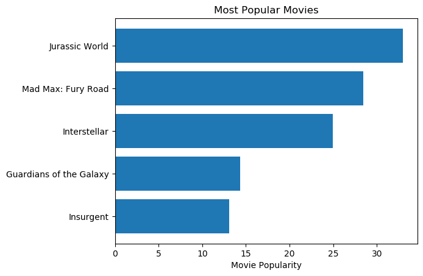

```python
#Creating a bar plot
plt.rcdefaults()
fig, ax = plt.subplots()

#Data to be plotted
top_movies = movies.nlargest(5, ['popularity']).original_title
top_popularities = movies.popularity.sort_values(ascending=False).head()
y_pos = np.arange(len(top_movies))

#And now, for the graph...
ax.barh(y_pos, top_popularities, align='center')
ax.set_yticks(y_pos)
ax.set_yticklabels(top_movies)
ax.invert_yaxis()
ax.set_xlabel('Movie Popularity')
ax.set_title('Most Popular Movies')

plt.show();

fig.set_size_inches((15, 8), forward=False)
fig.savefig("Imgs/MoviesByPopularity.png")
```

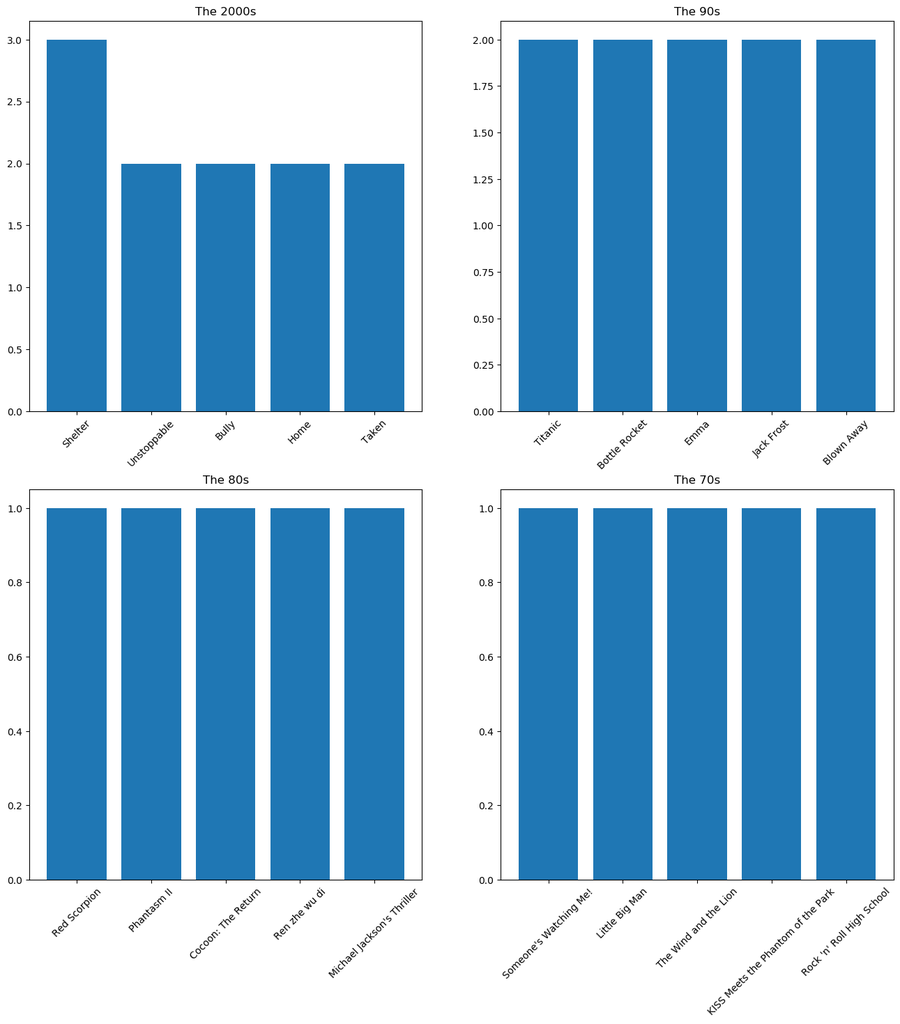

```python
the_70s_movies = movies.query('release_year >= 1970 and release_year <= 1979')['original_title'].value_counts().head()
the_80s_movies = movies.query('release_year >= 1980 and release_year <= 1989')['original_title'].value_counts().head()
the_90s_movies = movies.query('release_year >= 1990 and release_year <= 1999')['original_title'].value_counts().head()
the_2000s_movies = movies.query('release_year >= 2000 and release_year <= 2017')['original_title'].value_counts().head()

fig, axs = plt.subplots(2, 2, figsize=(16,16))

axs[0, 0].bar(the_2000s_movies.keys(), the_2000s_movies)
axs[0, 0].set_title('The 2000s')

axs[0, 1].bar(the_90s_movies.keys(), the_90s_movies)
axs[0, 1].set_title('The 90s')

axs[1, 0].bar(the_80s_movies.keys(), the_80s_movies)
axs[1, 0].set_title('The 80s')

axs[1, 1].bar(the_70s_movies.keys(), the_70s_movies)
axs[1, 1].set_title('The 70s')

for ax in fig.axes:
    plt.sca(ax)
    plt.xticks(rotation=45)

plt.show();
fig.savefig('Imgs/MoviesByYear.png')
```

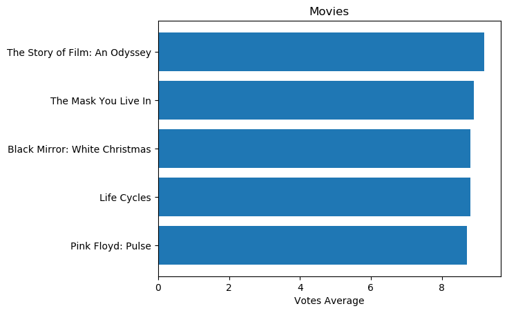

```python
#Creating a bar plot
plt.rcdefaults()
fig, ax = plt.subplots()

#Data to be plotted
top_movies = movies.nlargest(5, ['vote_average']).original_title
top_votes = movies.vote_average.sort_values(ascending=False).head()
y_pos = np.arange(len(top_movies))

#And now, for the graph...
ax.barh(y_pos, top_votes, align='center')
ax.set_yticks(y_pos)
ax.set_yticklabels(top_movies)
ax.invert_yaxis()
ax.set_xlabel('Votes Average')
ax.set_title('Movies')

plt.show();

fig.set_size_inches((12, 8), forward=False)
fig.savefig("Imgs/MoviesByValueCount.png")
```

```python
movie_rating = []
movie_rating.append(movies.query('vote_average >= 8.5').shape[0])
movie_rating.append(movies.query('vote_average < 8.5 and vote_average >= 6').shape[0])
movie_rating.append(movies.query('vote_average < 6 and vote_average >= 4.5').shape[0])
movie_rating.append(movies.query('vote_average < 4.5').shape[0])
movie_rating
```

```
[12, 5798, 4411, 644]
```

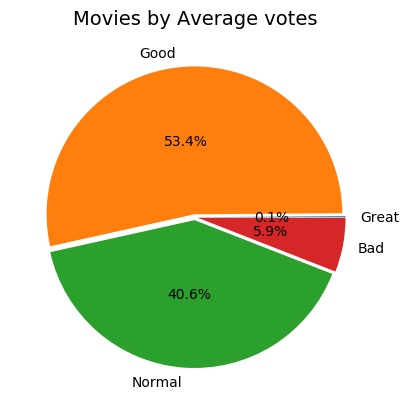

```python
pie, ax = plt.subplots()
labels = ['Great', 'Good', 'Normal', 'Bad']
plt.pie(x=movie_rating, autopct='%.1f%%', explode=[0.02]*4, labels=labels, pctdistance=0.5)
plt.title('Movies by Average votes', fontsize=14);
pie.savefig('Imgs/MoviesByAverageVotes.png')
```

#### Conclusions

> If you want to tackle the question of what are the best movies, you would have to look through different angles, for example, if you look at the popularity value of the movies you'll see that the following movies are the top 5

> ```
> - Jurassic world
> - Mad max: fury road
> - Interstellar
> - Guardians of the galaxy
> - Insurgent
> ```

> However, if you look at it by the votes average, you'll get the following top 5:

> ```
> - The story of film: an odyssey
> - The mask you live in
> - Black mirror: white christmas
> - Life cycles
> - Pink floyd: pulse
> ```

### *Addressed Question:* Does the movie budget affect its popularity?

```python
budgets = movies.nlargest(10, ['popularity']).budget
budgets = budgets/5e6 # Rescale the budgets
top_movies = movies.nlargest(10, ['popularity']).original_title
top_popularities = movies.popularity.sort_values(ascending=False).head(10)
```

```python
#Preparing values for xticks plot
ind = np.arange(len(budgets))  # the x locations for the groups
width = 0.35       # the width of the bars
```

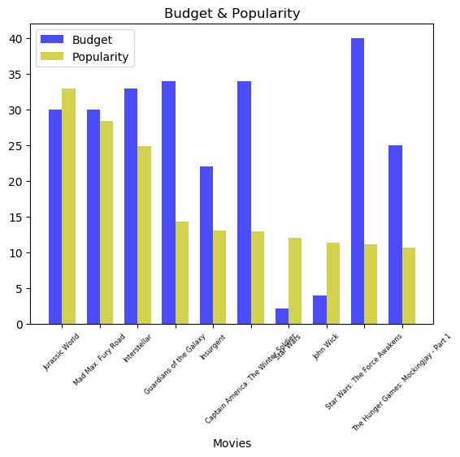

```python
fig = plt.figure()
blue_bars = plt.bar(ind, budgets, width, color='b', alpha=.7, label='Budget')
yellow_bars = plt.bar(ind + width, top_popularities, width, color='y', alpha=.7, label='Popularity')

plt.xlabel('Movies')
plt.title('Budget & Popularity')
locations = ind + width / 2
labels = top_movies
plt.xticks(locations, labels, fontsize=6, rotation=45)

plt.legend();
fig.savefig('Imgs/BudgetVsPopularity.png')
```

#### Conclusions:

> As you can see from the graph, there's no certain correlation between movie popularity and its budget. As the popularity of the movie increases, the budget does not has a certain pattern, it sometimes increases and sometimes decreases.

### *Addressed Question:* Does the movie runtime affect its popularity?

```python
runtimes = movies.nlargest(10, ['popularity']).runtime
top_movies = movies.nlargest(10, ['popularity']).original_title
top_popularities = movies.popularity.sort_values(ascending=False).head(10)
```

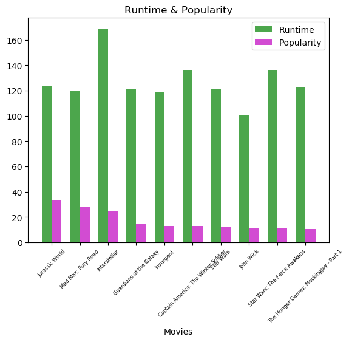

```python
fig = plt.figure()
green_bars = plt.bar(ind, runtimes, width, color='g', alpha=.7, label='Runtime')
magenta_bars = plt.bar(ind + width, top_popularities, width, color='m', alpha=.7, label='Popularity')

plt.xlabel('Movies')
plt.title('Runtime & Popularity')
locations = ind + width / 2
labels = top_movies
plt.xticks(locations, labels, fontsize=6, rotation=45)

plt.legend();
fig.savefig('Imgs/RuntimeVsPopularity.png')
```

#### Conclusions:

> As you can see from the graph, there's no certain correlation between movie popularity and its runtime. As the popularity of the movie increases, the runtime is almost the same. It does not has a certain pattern, it sometimes increases and sometimes decreases.

### *Addressed Question:* Which genres are most popular?

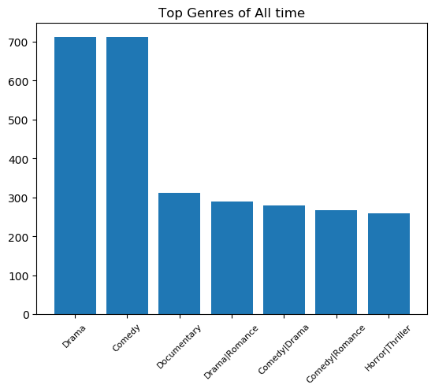

```python
top_genres = movies.genres.value_counts().sort_values(ascending=False).head(7)

plt.rcdefaults()
fig = plt.figure()
plt.bar(top_genres.keys(), top_genres)
plt.xticks(rotation=45, fontsize=8)
plt.title("Top Genres of All time")

plt.show();
fig.set_size_inches((8, 12), forward=False)
fig.savefig('Imgs/Genres.png')
```

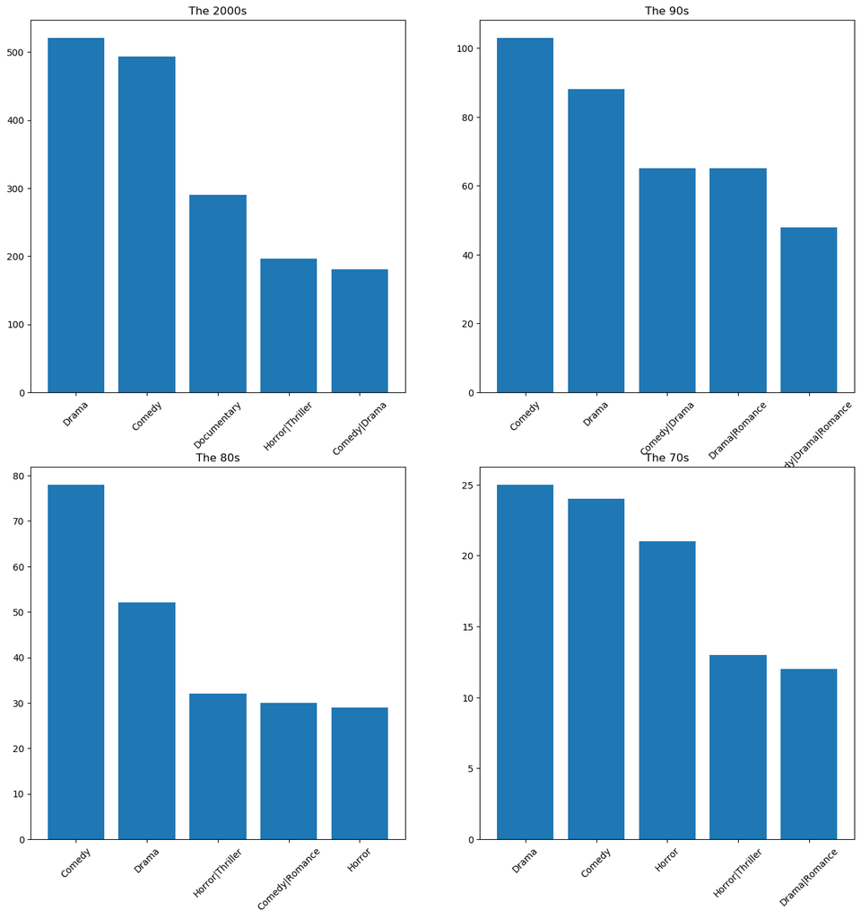

```python
the_70s_genres = movies.query('release_year >= 1970 and release_year <= 1979')['genres'].value_counts().head()
the_80s_genres = movies.query('release_year >= 1980 and release_year <= 1989')['genres'].value_counts().head()
the_90s_genres = movies.query('release_year >= 1990 and release_year <= 1999')['genres'].value_counts().head()
the_2000s_genres = movies.query('release_year >= 2000 and release_year <= 2017')['genres'].value_counts().head()

fig, axs = plt.subplots(2, 2, figsize=(16,16))

axs[0, 0].bar(the_2000s_genres.keys(), the_2000s_genres)
axs[0, 0].set_title('The 2000s')

axs[0, 1].bar(the_90s_genres.keys(), the_90s_genres)
axs[0, 1].set_title('The 90s')

axs[1, 0].bar(the_80s_genres.keys(), the_80s_genres)
axs[1, 0].set_title('The 80s')

axs[1, 1].bar(the_70s_genres.keys(), the_70s_genres)
axs[1, 1].set_title('The 70s')

for ax in fig.axes:
    plt.sca(ax)
    plt.xticks(rotation=45)

plt.show();
fig.savefig('Imgs/GenresByYear.png')
```

#### Conclusions

> The top genres differ slightly over time. On average the best genres are:

> ```
> - Comedy
> - Drama
> - Horror
> ```

### *Addressed Question:* Do certain genres get a higher budget than others?

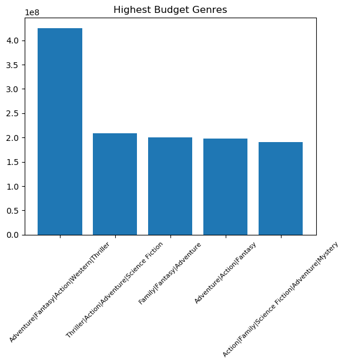

```python
highest_budget_genres = movies.groupby(['genres']).mean().sort_values(ascending=False, by='budget').head()['budget']

fig = plt.figure()
plt.bar(highest_budget_genres.keys(), highest_budget_genres, align='center')
plt.xticks(rotation=45, fontsize=8)
plt.title("Highest Budget Genres")
plt.show();

fig.set_size_inches((10, 20), forward=False)
fig.savefig('Imgs/HighBudgetGenres.png')
```

### Revenue & Budget Analysis

### *Addressed Question:* How does the movie revenues change every year?

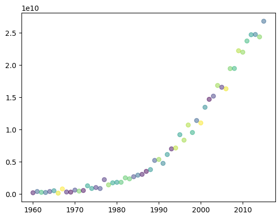

```python
revenues_across_years = movies.groupby(['release_year']).sum()['revenue']

x = revenues_across_years.keys()
y = revenues_across_years
colors = np.random.rand(len(revenues_across_years))

fig = plt.figure()
plt.scatter(x, y, c=colors, alpha=0.5)
plt.show();
fig.savefig('Imgs/Revenues.png')
```

### *Addressed Question:* How does the movie budget change every year?

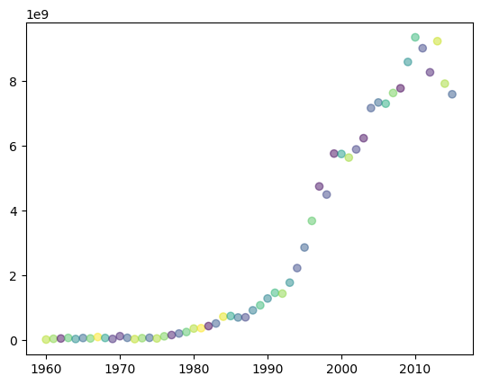

```python
budgets_across_years = movies.groupby(['release_year']).sum()['budget']

x = budgets_across_years.keys()
y = budgets_across_years
colors = np.random.rand(len(budgets_across_years))

fig = plt.figure()
plt.scatter(x, y, c=colors, alpha=0.5)
plt.show();
fig.savefig('Imgs/Budgets.png')
```

### *Addressed Question:* What are the budgets & Revenues of the most popular genres?

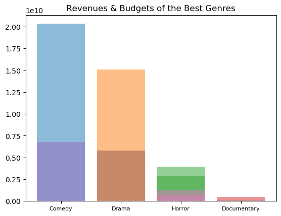

```python
revenue_of_comedy = movies.query('genres == "Comedy"').groupby(['genres']).sum()['revenue']
revenue_of_drama = movies.query('genres == "Drama"').groupby(['genres']).sum()['revenue']
revenue_of_doc = movies.query('genres == "Documentary"').groupby(['genres']).sum()['revenue']
revenue_of_horror = movies.query('genres == "Horror" or genres == "Horror|Thriller"').groupby(['genres']).sum()['revenue']

budget_of_comedy = movies.query('genres == "Comedy"').groupby(['genres']).sum()['budget']
budget_of_drama = movies.query('genres == "Drama"').groupby(['genres']).sum()['budget']
budget_of_doc = movies.query('genres == "Documentary"').groupby(['genres']).sum()['budget']
budget_of_horror = movies.query('genres == "Horror" or genres == "Horror|Thriller"').groupby(['genres']).sum()['budget']

fig = plt.figure()
plt.bar(['Comedy'], revenue_of_comedy, alpha=0.5)
plt.bar(['Drama'], revenue_of_drama, alpha=0.5)
plt.bar(['Horror'], revenue_of_horror, alpha=0.5)
plt.bar(['Documentary'], revenue_of_doc, alpha=0.5)

plt.bar(['Comedy'], budget_of_comedy, alpha=0.5)
plt.bar(['Drama'], budget_of_drama, alpha=0.5)
plt.bar(['Horror'], budget_of_horror, alpha=0.5)
plt.bar(['Documentary'], budget_of_doc, alpha=0.5)

plt.xticks(fontsize=8)
plt.title("Revenues & Budgets of the Best Genres")
plt.show();
fig.savefig('Imgs/Revenues&BudgetsOfGenres.png')
```

### Directors & Production Companies Analysis

### *Addressed Question:* Which Production Companies are the most popular?

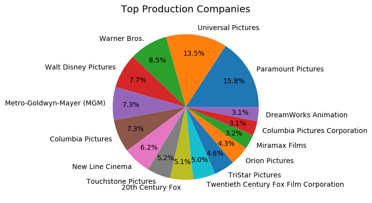

```python
prod_companies = movies.production_companies.value_counts().head(16)
prod_companies = prod_companies[prod_companies.keys() != 'empty']

pie, ax = plt.subplots()
labels = prod_companies.keys()
plt.pie(x=prod_companies, autopct='%.1f%%', labels=labels, pctdistance=0.75)
plt.title('Top Production Companies', fontsize=14);
pie.savefig('Imgs/ProductionsCompanies.png')
```

### *Addressed Question:* Which directors are the most popular?

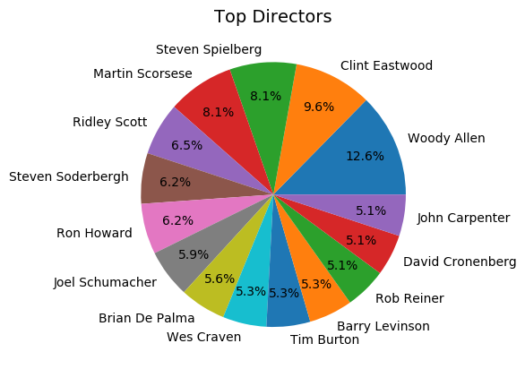

```python
directors = movies.director.value_counts().head(16)
directors = directors[directors.keys() != 'empty']

pie, ax = plt.subplots()
labels = directors.keys()
plt.pie(x=directors, autopct='%.1f%%', labels=labels, pctdistance=0.75)
plt.title('Top Directors', fontsize=14);
pie.savefig('Imgs/Directors.png')
```

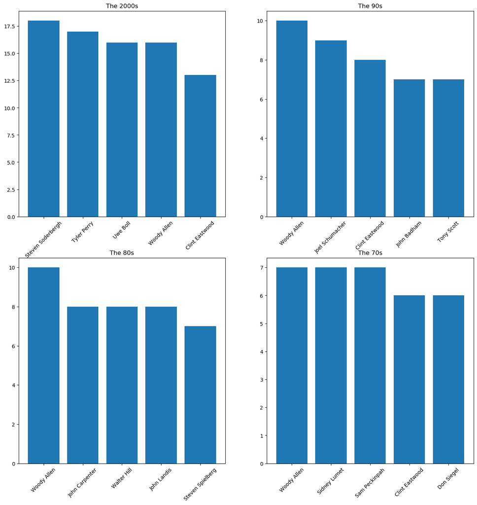

```python
the_70s_directors = movies.query('release_year >= 1970 and release_year <= 1979')['director'].value_counts().head()
the_80s_directors = movies.query('release_year >= 1980 and release_year <= 1989')['director'].value_counts().head()
the_90s_directors = movies.query('release_year >= 1990 and release_year <= 1999')['director'].value_counts().head()
the_2000s_directors = movies.query('release_year >= 2000 and release_year <= 2017')['director'].value_counts().head(6)
the_2000s_directors = the_2000s_directors[the_2000s_directors.keys() != 'empty']

fig, axs = plt.subplots(2, 2, figsize=(16,16))

axs[0, 0].bar(the_2000s_directors.keys(), the_2000s_directors)
axs[0, 0].set_title('The 2000s')

axs[0, 1].bar(the_90s_directors.keys(), the_90s_directors)
axs[0, 1].set_title('The 90s')

axs[1, 0].bar(the_80s_directors.keys(), the_80s_directors)
axs[1, 0].set_title('The 80s')

axs[1, 1].bar(the_70s_directors.keys(), the_70s_directors)
axs[1, 1].set_title('The 70s')

for ax in fig.axes:
    plt.sca(ax)
    plt.xticks(rotation=45)

plt.show();
fig.savefig('Imgs/DirectorsByYear.png')
```